# 每週一圖作業繪圖說明檔

#### 環境設定

以下為老師執行時一定會存在的環境設定

```r
rm(list=ls())
library(dplyr); library(stringr); library(ggplot2); library(plotly); library(lubridate); library(readr); library(colorspace); library(grDevices); library(shiny); library(shinyjs); library(scales)
library(tidyr); library(showtext); library(tidyverse); library(colorspace)

#font_add("QYuan","cwTeXQYuan-Medium.ttf") # 新增字體
showtext_auto(enable=TRUE) #啟用字體
theme_set(theme_classic())
knitr::opts_chunk$set(fig.align='center', fig.showtext=T)
```

#### 繪圖程式

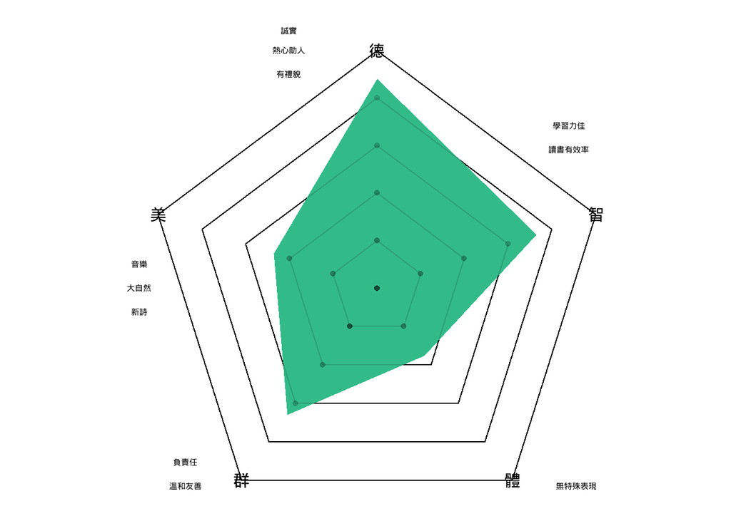

```r
load("graphData.Rda")
graphData$back%>%
  ggplot()+
  geom_path(
    aes(x=x1,y=y1)
  )+
  geom_path(
    aes(x=x2,y=y2)
  )+
  geom_path(
    aes(x=x3,y=y3)
  )+
  geom_path(
    aes(x=x4,y=y4)
  )+
  geom_path(
    aes(x=x5,y=y5)
  )+
  theme(aspect.ratio = 1,
        axis.line = element_blank(),
        axis.title = element_blank(),
        axis.text = element_blank(),
        axis.ticks = element_blank())+
  geom_polygon(
    data = graphData$I,
    mapping = aes(x=x,y=y),
    fill="#32bb89"
  )+
  geom_text(
    mapping = aes(x=graphData$back$x5,
                  y=graphData$back$y5,
                  label=graphData$back$label),size=8
  )+
  geom_path(
    aes(x=x1,y=y1),alpha=0.15
  )+
  geom_path(
    aes(x=x2,y=y2),alpha=0.15
  )+
  geom_path(
    aes(x=x3,y=y3),alpha=0.15
  )+
  geom_path(
    aes(x=x4,y=y4),alpha=0.15
  )+
  geom_path(
    aes(x=x5,y=y5),alpha=0.15
  )+
  geom_point(
    data = graphData$o,
    mapping =
      aes(x=x,y=y),
      alpha=0.6
  )+
  annotate(
    "text",
    x=-2.3,y=c(6,5.4,6.5),
    label=c("熱心助人","有禮貌","誠實")
  )+
  annotate(
    "text",
    x=5,y=c(3.5,4.1),
    label=c("讀書有效率","學習力佳")
  )+
  annotate(
    "text",
    x=5.2,y=c(-5),
    label=c("無特殊表現")
  )+
  annotate(
    "text",
    x=-5,y=c(-5,-4.4),
    label=c("溫和友善","負責任")
  )+
  annotate(
    "text",
    x=-6.2,y=c(0.6,0,-0.6),
    label=c("音樂","大自然","新詩")
  )+
  geom_point(
    data = graphData$p1,
    mapping = aes(x=x,y=y),alpha=0.3
  )+
  geom_point(
    data = graphData$p2,
    mapping = aes(x=x,y=y),alpha=0.25
  )+
  geom_point(
    data = graphData$p3,
    mapping = aes(x=x,y=y),alpha=0.2
  )+
  geom_point(
    data = graphData$p4,
    mapping = aes(x=x,y=y),alpha=0.15
  )
```

#### 設計說明

說明想傳達的訊息（必要）及設計想法（非必要）。寫在***下一行。

此圖可以看到我**自覺**在**五育之中較為突出以及較為缺乏的項目**。

因為我的資料幾乎不是數據，故無法運用`散佈圖`、`盒狀圖`等圖形，所以我選用`雷達圖`，並且擅自將資料量化。

使用`雷達圖`來表達這些資料的**優點**是能將不同種類的資料分成幾個大類別後，再依據某些原則，點出各分類的位置。其將**大幅簡化比較種種資料的過程**，我們可以清楚比對原始種種資料在各分類的相對強度。

這些資料使用`雷達圖`表現的**缺點**包括: 1.沒有(無法)將資料經過量化、標準化等步驟。故該圖形**非常的主觀**，沒有參考依據。 2.**許多資訊無法被表達出來**。(舉例來說，“樂觀”便不屬於任何一類；又或者無法使用合適的方式，表現“記性差”在“智”的分類中，具有扣分效果。)